# User Guide: 1 Grammar of Graphics

## Averages and similar summaries

Our summary *statistics* are quite different to `ggplot2`s `stat_summary()`. One could criticize that they calculates summaries using a grouping that is not based on a *ggplot* *aesthetic*. This is a deviation from the grammar of graphics but allows the calculation of summaries for an arbitrary region of the range of $x$-values in the spectral data.

### Summaries producing graphical elements

Three *statistics* generate only graphic output. First we demonstrate `stat_wb_box()` that produces a filled box for each waveband, filled with the color corresponding to the waveband.

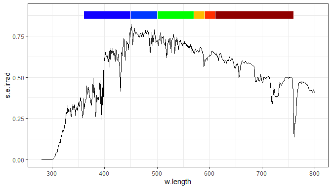

```r
ggplot(sun.spct) + geom_line() +
  stat_wb_box(w.band = VIS_bands(), color = "white") +
  scale_fill_identity()
```

The *statistics* `stat_wb_column` outputs a column for each waveband, with an area equal to the integral for the corresponding region of the spectrum.

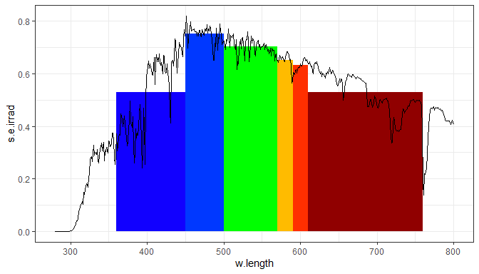

```r
ggplot(sun.spct) + stat_wb_column(w.band = VIS_bands()) + geom_line() +
  scale_fill_identity()
```

The *statistic* `stat_wd_hbar` outputs a horizontal bar showing the mean spectral *y*-value for each waveband.

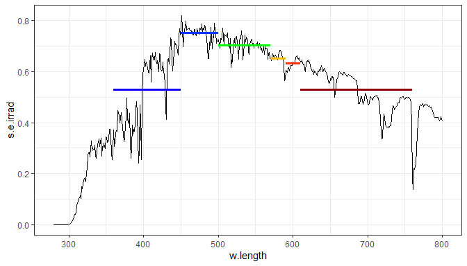

```r
ggplot(sun.spct) + geom_line() +
  stat_wb_hbar(w.band = VIS_bands(), size = 1.2) +
  scale_color_identity()
```

These graphical summaries are frequently used together with text and label elements with names or numerical summaries.

### Name labels

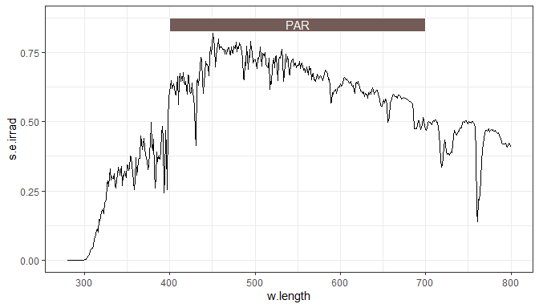

```r
ggplot(sun.spct) + geom_line() +
  stat_wb_box(w.band = PAR(), color = "white", ypos.fixed = 0.85) +
  stat_wb_label(w.band = PAR(), ypos.fixed = 0.85) +
  scale_fill_identity() + scale_color_identity()
```

### Summaries by wavelength range

The summary is calculated for a range of wavelengths, and the `range` argument defaults to the range of wavelengths in each group defined by other aesthetics. The default *geom* is `"text"`.

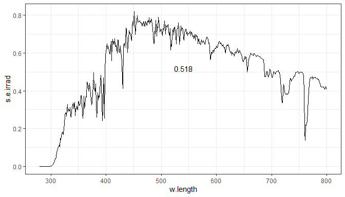

```r
ggplot(sun.spct) + geom_line() + stat_wl_summary()
```

We can optionally supply an argument for `range` to limit the summary to a certain part of the spectrum, in which case the use of the default `"text"` *geom* is misleading. We add the line last so that it is drawn on top of the rectangle.

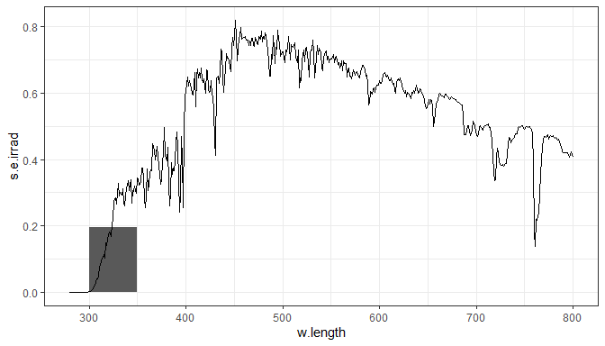

```r
ggplot(sun.spct) +
  stat_wl_summary(range = c(300,350), geom = "rect") +
  geom_line()
```

Here we show how to add horizontal line and label for the overall mean, by adding the same stat twice, using different values for `geom`.

[figure not shown]

```r
ggplot(sun.spct) +
  geom_line() +
  stat_wl_summary(geom = "hline", color = "red") +
  stat_wl_summary(label.fmt = "Mean = %.3g", color = "red", vjust = -0.3)
```

Or we can add the *aesthetic* twice with two different geoms to get the value plotted as a rectangular area and the value as formatted text. We use `vjust` to move the text above the end of the bar, instead of it being centred on the value itself.

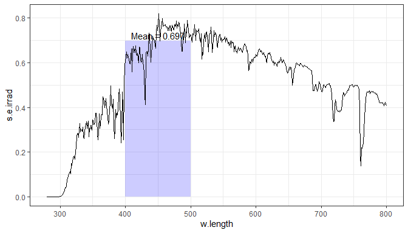

```r
ggplot(sun.spct) +
  stat_wl_summary(range = c(400,500),
                  geom = "rect",
                  alpha = 0.2,
                  fill = color_of(450)) +
  stat_wl_summary(range = c(400,500),
                  label.fmt = "Mean = %.3g",
                  vjust = -0.3,
                  geom = "text") +
  geom_line()
```

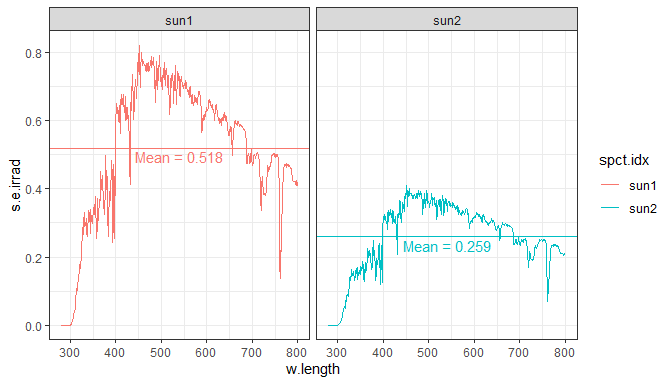

```r
ggplot(two_suns.spct) + aes(color = spct.idx) +
  geom_line() +
  stat_wl_summary(geom = "hline") +
  stat_wl_summary(label.fmt = "Mean = %.3g", vjust = 1.2, show.legend = FALSE) +
  facet_grid(cols = vars(spct.idx))
```

Same example as above but using a free scale for $y$, still working as expected.

[figure not shown]

```r
ggplot(two_suns.spct) + aes(color = spct.idx) +
  geom_line() +
  stat_wl_summary(geom = "hline") +
  stat_wl_summary(label.fmt = "Mean = %.3g", vjust = 1.2, show.legend = FALSE) +
  facet_grid(cols = vars(spct.idx), scales = "free_y")
```

### Means by waveband

Our `stat_wb_mean()` is quite different to `ggplot2`s `stat_summary()`. One could criticize that it calculates summaries using a grouping that is not based on a *ggplot* *aesthetic*. This is a deviation from the grammar of graphics but allows the calculation of summaries for an arbitrary waveband of the spectrum based on `photobiology::waveband` objects, or lists of such objects. In contrast to `stat_wl_summary()` this allows the use of several ranges, and also of different weighting functions. This function returns both mean and total values for each waveband. It differs from `stat_wb_total()` only in the default *aesthetics* set.

The first example uses a `waveband` object created on-the-fly and defining a range of wavelengths.

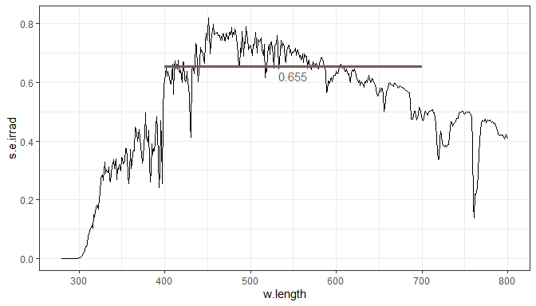

```r
ggplot(sun.spct) +
  geom_line() +
  stat_wb_hbar(w.band = PhR(), size = 1.3) +
  stat_wb_mean(aes(color = after_stat(wb.color)), w.band = PhR(), ypos.mult = 0.95) +
  scale_color_identity() +
  scale_fill_identity()
```

If a numeric vector or a spectrum is supplied as argument to `waveband`, its range is calculated and used to construct a temporary `waveband` object.

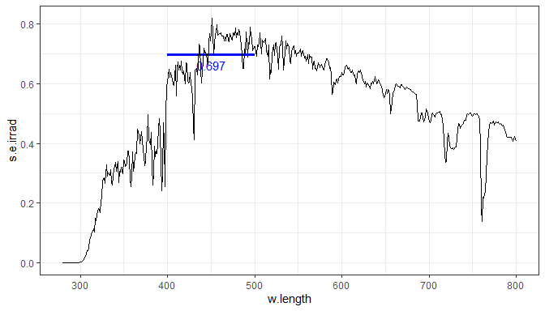

```r
ggplot(sun.spct) +
  stat_wb_hbar(w.band = c(400,500), size = 1.2) +
  stat_wb_mean(aes(color = after_stat(wb.color)),
               w.band = c(400,500), ypos.mult = 0.95) +
  geom_line() +
  scale_color_identity() +
  scale_fill_identity()
```

Lists of wavebands, either user-defined or as in this case using a list constructor can be also used.

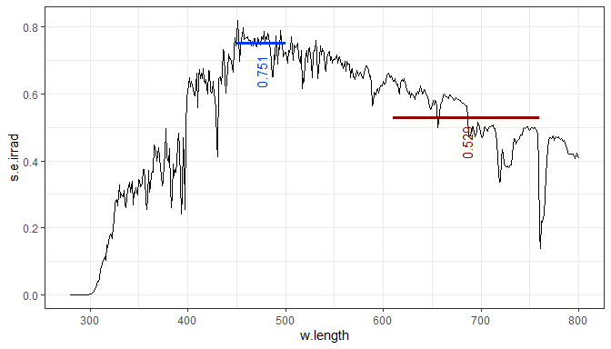

```r
ggplot(sun.spct) +
  geom_line() +
  stat_wb_hbar(w.band = list(Blue(), Red()), size = 1.2) +
  stat_wb_mean(aes(color = after_stat(wb.color)),
               w.band = list(Blue(), Red()), ypos.mult = 0.95,
               hjust = 1, angle = 90) +
  scale_color_identity() +
  scale_fill_identity()
```

### Totals by waveband

Our `stat_wb_total()` is quite different to `ggplot2`s `stat_summary()`. One could criticize that it calculates summaries using a grouping that is not based on a *ggplot* *aesthetic*. This is a deviation from the grammar of graphics but allows the calculation of summaries for an arbitrary waveband of the spectrum based on `photobiology::waveband` objects, or lists of such objects. In contrast to `stat_wl_summary()` this allows the use of several ranges, and also of different weighting functions. This function returns both mean and total values for each waveband. It differs from `stat_wb_mean()` only in the default *aesthetics* set.

The first example uses a `waveband` object created on-the-fly and defining a range of wavelengths.

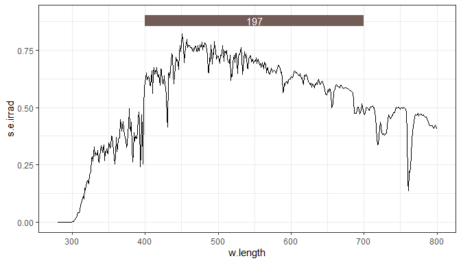

```r
ggplot(sun.spct) +
  stat_wb_box(w.band = PhR()) +
  stat_wb_total(w.band = PhR()) +
  geom_line() +
  scale_color_identity() +
  scale_fill_identity()
```

If a numeric vector or a spectrum is supplied as argument to `waveband`, its range is calculated and used to construct a temporary `waveband` object.

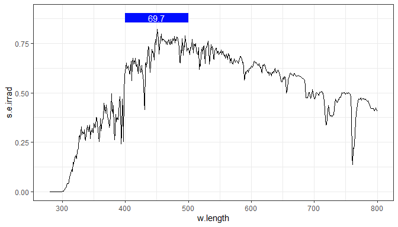

```r
ggplot(sun.spct) +
  stat_wb_box(w.band = c(400,500)) +
  stat_wb_total(w.band = c(400,500)) +
  geom_line() +
  scale_color_identity() +
  scale_fill_identity()
```

Lists of wavebands, either user-defined or as in this case using constructor defined in package `photobiologyWavebands` can be also used. In the case of totals, areas represent them graphically in a very useful way.

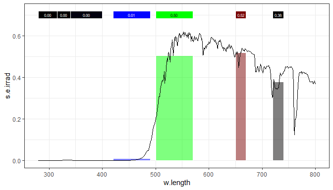

```r
ggplot(sun.spct * yellow_gel.spct) +
  stat_wb_box(w.band = Plant_bands(), color = "white", ypos.fixed = 0.7) +
  stat_wb_column(w.band = Plant_bands(), color = "white", alpha = 0.5) +
  stat_wb_mean(w.band = Plant_bands(), label.fmt = "%1.2f",
               ypos.fixed = 0.7, size = 2) +
  geom_line() +
  scale_fill_identity() + scale_color_identity()
```

### Irradiances by waveband

The _stat_s in previous sections can be used for non-weighed irradiances, but not for BSWFs. These `irrad` _stat_s have additional formal parameters for passing metadata, and use method `photobiology::irrad()` internally on a `photobiology::source_spct` object constructed from the data for $x$ and $y$ *aesthetics*. Function `stat_wb_sirrad()` is equivalent to `stat_wb_mean()` and function `stat_wb_irrad()` is equivalent to `stat_wb_total()` following the same naming convention as in package `photobiology`.

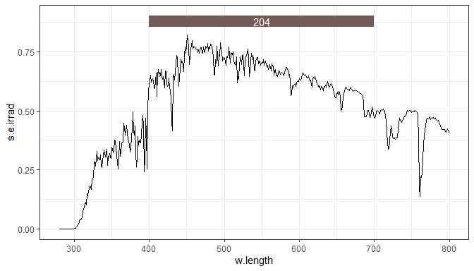

```r
ggplot(sun.spct) +
  stat_wb_box(w.band = PAR()) +
  stat_wb_irrad(w.band = PAR(), unit.in = "energy", time.unit = "second") +
  geom_line() +
  scale_color_identity() +
  scale_fill_identity()
```

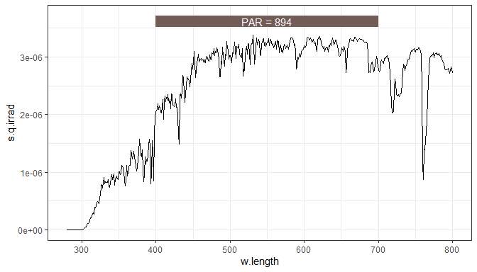

```r
ggplot(sun.spct, unit.out = "photon") +
  stat_wb_box(w.band = PAR()) +
  stat_wb_irrad(w.band = PAR(),
                unit.in = "photon", time.unit = "second",
                aes(label = sprintf("%s = %.3g",
                                    after_stat(wb.name),
                                    after_stat(wb.yint) * 1e6))) +
  geom_line() +
  scale_color_identity() +
  scale_fill_identity()
```

Also following the same naming convention as in package `photobiology`, `e` and `q` versions of these functions default to energy and photon based quantities to `"seconds"` for time unit.

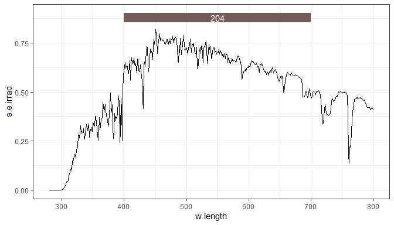

```r
ggplot(sun.spct) +
  stat_wb_box(w.band = PAR()) +
  stat_wb_e_irrad(w.band = PAR()) +
  geom_line() +
  scale_color_identity() +
  scale_fill_identity()
```

We can also use `waveband` objects describing *biological spectral weighting functions* (BSWFs), such as CIE’s erythema function.

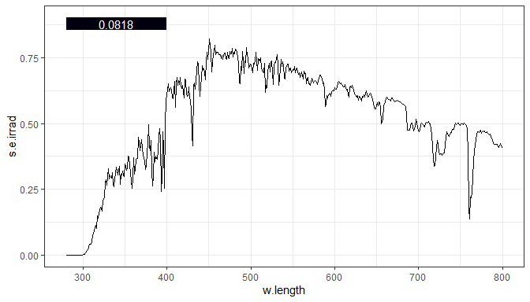

```r
ggplot(sun.spct) +
  stat_wb_box(w.band = CIE()) +
  stat_wb_e_irrad(w.band = CIE()) +
  geom_line() +
  scale_color_identity() +
  scale_fill_identity()
```

For daily data we need to override the default time unit.

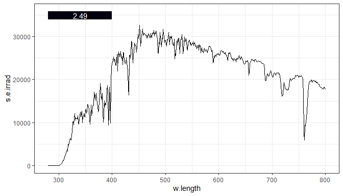

```r
ggplot(sun.daily.spct) +
  stat_wb_box(w.band = CIE()) +
  stat_wb_e_irrad(w.band = CIE(), time.unit = "day", label.mult = 1e-3) +
  geom_line() +
  scale_color_identity() +
  scale_fill_identity()
```

Here we pass a list of `waveband` objects. And add areas to facilitate comparisons as irradiances are integral over wavelengths.

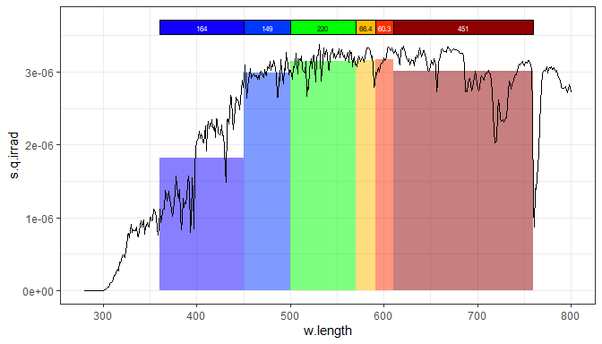

```r
ggplot(sun.spct, unit.out = "photon") +
  stat_wb_box(w.band = VIS_bands(), color = "black") +
  stat_wb_column(w.band = VIS_bands(), color = NA, alpha = 0.5) +
  stat_wb_q_irrad(w.band = VIS_bands(), label.mult = 1e6, size = 2) +
  geom_line() +
  scale_color_identity() +
  scale_fill_identity()
```

### Spectral irradiances by waveband

Spectral irradiances are equivalent to means, and can be best represented graphically as horizontal bars.

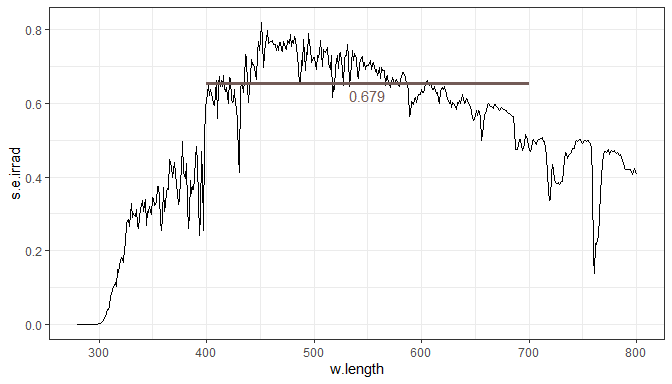

```r
ggplot(sun.spct) +
  geom_line() +
  stat_wb_hbar(w.band = PAR(), size = 1.4) +
  stat_wb_e_sirrad(aes(color = after_stat(wb.color)),
                   w.band = PAR(), ypos.mult = 0.95) +
  scale_color_identity() +
  scale_fill_identity()
```

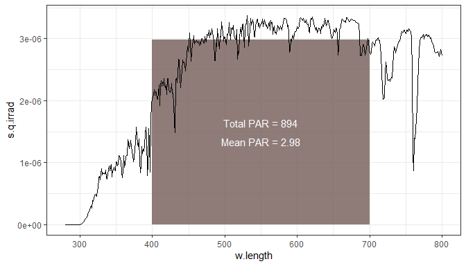

```r
ggplot(sun.spct, unit.out = "photon") +
  stat_wb_column(w.band = PAR(), alpha = 0.8) +
  stat_wb_q_sirrad(w.band = PAR(),
                   mapping =
                     aes(label = sprintf("Total %s = %.3g",
                                         after_stat(wb.name),
                                         after_stat(wb.yint) * 1e6)),
                   ypos.mult = 0.55) +
  stat_wb_q_sirrad(w.band = PAR(),
                   mapping =
                     aes(label = sprintf("Mean %s = %.3g",
                                         after_stat(wb.name),
                                         after_stat(wb.ymean) * 1e6)),
                   ypos.mult = 0.45) +
  geom_line() +
  scale_color_identity() +
  scale_fill_identity()
```

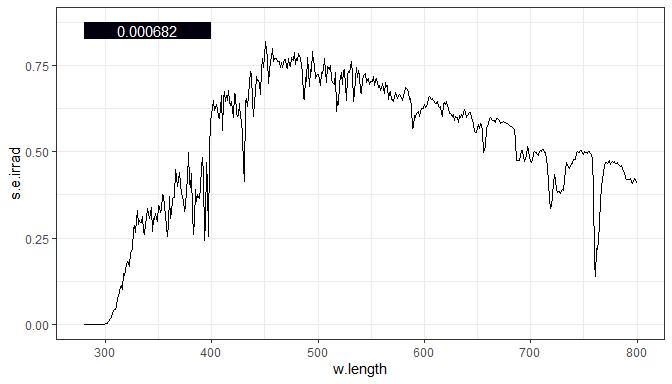

```r
ggplot(sun.spct) +
  stat_wb_box(w.band = waveband(CIE()), ypos.fixed = 0.85) +
  stat_wb_e_sirrad(w.band = CIE(), ypos.fixed = 0.85) +
  geom_line() +
  scale_color_identity() +
  scale_fill_identity()
```

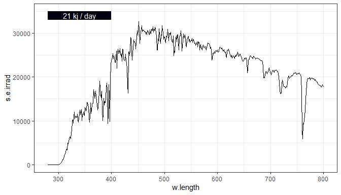

```r
ggplot(sun.daily.spct) +
  stat_wb_box(w.band = waveband(CIE()), ypos.fixed = 34e3) +
  stat_wb_e_sirrad(w.band = CIE(),
                   label.fmt = "%.2g kj / day",
                   time.unit = "day",
                   ypos.fixed = 34e3) +
  geom_line() +
  scale_color_identity() +
  scale_fill_identity()
```

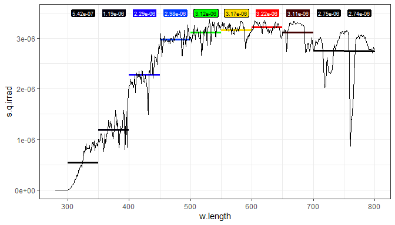

```r
my.bands <- split_bands(c(300,800), length.out = 10)
ggplot(sun.spct, unit.out = "photon") +
  stat_wb_hbar(w.band = my.bands, size = 1.4) +
  stat_wb_q_sirrad(geom = "label", w.band = my.bands,
                   size = 2.5, ypos.fixed = 3.5e-6) +
  geom_line() +
  scale_color_identity() +
  scale_fill_identity()
```

### Irradiances by waveband

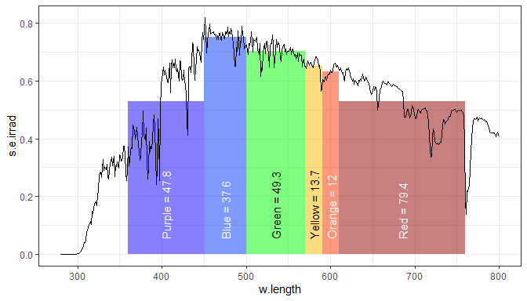

```r
ggplot(sun.spct) +
  stat_wb_column(w.band = VIS_bands(), alpha = 0.5) +
  stat_wb_e_irrad(w.band = VIS_bands(), angle = 90,
                   ypos.fixed = 0.05, hjust = 0,
                   aes(label = paste(after_stat(wb.name),
                                     after_stat(y.label),
                                     sep = " = "))) +
  geom_line() +
  scale_color_identity() +
  scale_fill_identity()
```

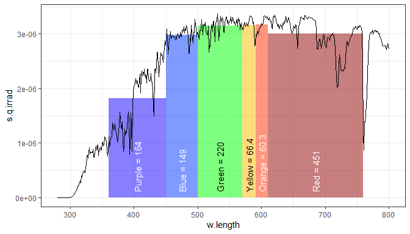

```r
ggplot(sun.spct, unit.out = "photon") +
  stat_wb_column(w.band = VIS_bands(), alpha = 0.5) +
  stat_wb_q_irrad(w.band = VIS_bands(), angle = 90,
                  label.mult = 1e6, ypos.fixed = 1e-7, hjust = 0,
                  aes(label = paste(after_stat(wb.name),
                                    after_stat(y.label),
                                    sep = " = "))) +
  geom_line() +
  scale_color_identity() +
  scale_fill_identity()
```

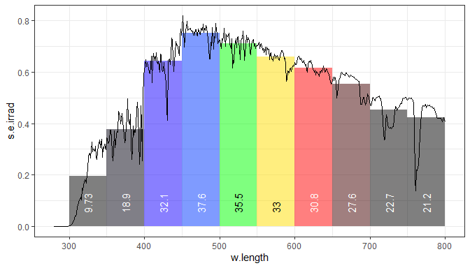

```r
my.bands <- split_bands(c(300,800), length.out = 10)
ggplot(sun.spct) +
  stat_wb_column(w.band = my.bands, alpha = 0.5) +
  stat_wb_e_irrad(w.band = my.bands, angle = 90,
                  ypos.fixed = 0.05, hjust = 0) +
  geom_line() +
  scale_color_identity() +
  scale_fill_identity()
```